# Exercises STAT340 - ANOVA - part I

**Colloquium exercises:** You are encouraged to work together in groups on the exercises. Sharing problems and solutions is often a much quicker way to learn, especially for problems of a more practical nature.

This exercise session will be led by Elias through zoom. Join the meeting below to get assistance on Thursday from 14:15 to 16:00

https://nmbu.zoom.us/j/66481255218?pwd=qgcDFZ3T7MxuLVAARpw8ukot98Qhv0.1

Meeting ID: 664 8125 5218

Passcode: 406893

# 1 Ex-1: Chlorine levels in cities

Independent measurements of chlorine (ppm parts per million) were taken from 3 large cities:

```
##    City1 City2 City3
## 1   0.46  1.21  0.44
## 2   0.92 10.86  0.71
## 3   0.86  2.09  2.87
## 4   0.33  6.76  0.81
## 5   0.53  3.20  7.34
## 6   5.13  2.02  2.21
## 7   1.51  2.16  9.00
## 8   1.00  0.44 17.20
## 9   0.70  7.80  2.76
## 10  1.89  1.20  1.07
## 11  0.68  1.39  2.07
## 12  0.71  2.42  1.70
## 13  0.41  1.62  7.89
## 14  0.78 10.78  0.79
## 15  0.11  3.25  0.24
## 16  2.70  0.41  4.44
## 17  0.41  0.52 15.40
## 18  0.75  3.71  4.21
## 19  0.81  5.20  8.63
## 20  0.35 13.89  3.90
```

- Load the city dataset from the BIASdata R-package.

Before analyzing the data it is best to “stack” the data into two columns, a response column “y” and a city factor column “city”. This can be done using the function stack() in RStudio. You can name your data set as “citydata”, the response variable as “y” and the factor as “city”. Try to do this by the function colnames().

**Solution**

Rstudio:

```r
citydata <- stack(city)
colnames(citydata)<-c("y", "city")
```

The top of your data should look like this:

```
##       y  city
## 1  0.46 City1
## 2  0.92 City1
## 3  0.86 City1
## 4  0.33 City1
## 5  0.53 City1
## 6  5.13 City1
## 7  1.51 City1
## 8  1.00 City1
## 9  0.70 City1
## 10 1.89 City1
```

- Assume an ANOVA-model with chlorine as response and city as a factor. What assumptions do you make?

**Solution**

The model assumptions are:
$$y_{ij} =
\mu_i + \epsilon_{ij}$$
where the error terms are assumed independent and identically distributed $\epsilon_{ij} \sim N(0, \sigma^2)$. Further $\mu_i$ is the expected chlorine level in city $i$.

- Make a box-plot of the data using the Boxplot-function in the ‘car’-package Describe the variabilities between cities and within cities.

**Solution**

```r
library(car)
```

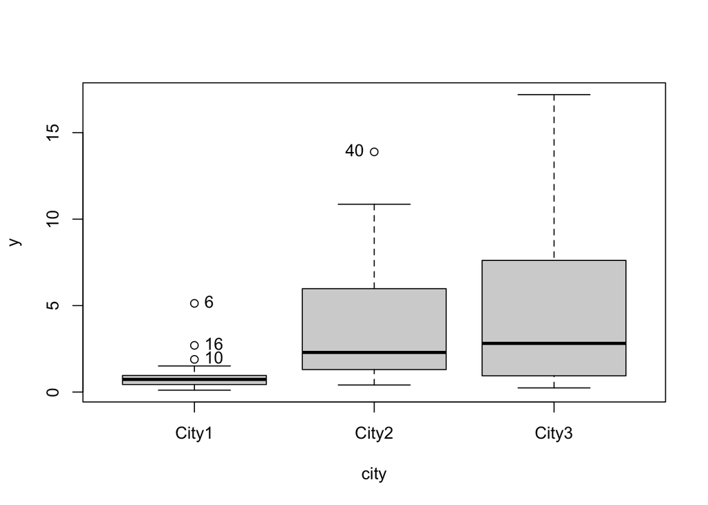

```
## [1] "6"  "10" "16" "40"
```

```r
Boxplot(y~city, data=citydata, id.method="y")
```

City 1 seems to have both the lowest average chlorine levels and the smallest variability in the measurements. Cities 2 and 3 are quite similar with both higher means and variability.

- Fit the model (using sum to zero parametrization) and perform a residual analysis. Comment on the model fit.

**Solution**

The fitted model:

```r
options(contrasts=c("contr.sum", "contr.poly"))
citymod1 <- lm(y ~ city, data=citydata)
summary(citymod1, cor=FALSE)
```

```
##
## Call:
## lm(formula = y ~ city, data = citydata)
##
## Residuals:
##    Min     1Q Median     3Q    Max
## -4.444 -2.438 -0.617  0.553 12.516
##
## Coefficients:
##             Estimate Std. Error t value Pr(>|t|)
## (Intercept)   3.2608     0.4741   6.878 5.07e-09 ***
## city(City1)  -2.2088     0.6704  -3.295   0.0017 **
## city(City2)   0.7857     0.6704   1.172   0.2461
## ---
## Signif. codes:  0 '***' 0.001 '**' 0.01 '*' 0.05 '.' 0.1 ' ' 1
##
## s: 3.672 on 57 degrees of freedom
## Multiple R-squared: 0.1637,
## Adjusted R-squared: 0.1343
## F-statistic: 5.578 on 2 and 57 DF,  p-value: 0.006132
```

```r
anova(citymod1)
```

```
## Analysis of Variance Table
##
## Response: y
##           Df Sum Sq Mean Sq F value   Pr(>F)
## city       2 150.43  75.216  5.5779 0.006132 **
## Residuals 57 768.62  13.485
## ---
## Signif. codes:  0 '***' 0.001 '**' 0.01 '*' 0.05 '.' 0.1 ' ' 1
```

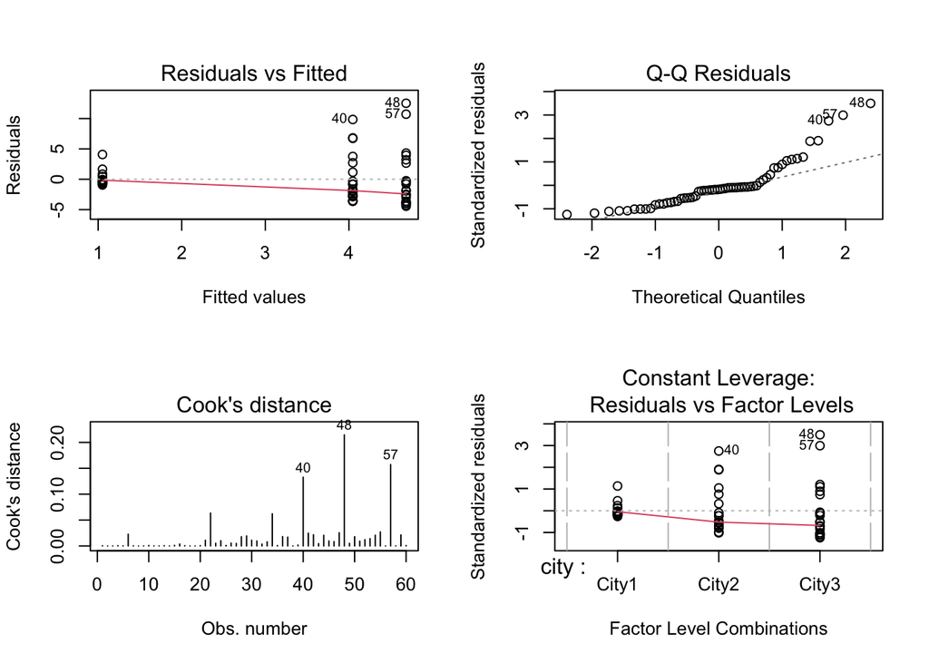

```r
par(mfrow=c(2,2))
plot(citymod1, which=c(1,2,4,5))
```

The residual analysis reveals two problems: 1) Non-constant variability, which was also observed in the boxplot, and 2) A skeewed and non-normal distribution for the residuals with a heavy tail to the right. The $R^2$ is quite small, only 16.4%, so there is a lot of unexplained variation in the response variable. The hypothesis test of effect of the group variable `city` appears to be highly significant, but we should be careful conluding about the effect of city until we have tried to improve the model fit.

- Make a log-transformation of $y$ to create the variable `logy`

```r
citydata$logy <- log(citydata$y)
```

- Fit a new model with `logy` as response and check the model fit again.

**Solution**

```
##
## Call:
## lm(formula = logy ~ city, data = citydata)
##
## Residuals:
##      Min       1Q   Median       3Q      Max
## -2.39867 -0.59544 -0.01755  0.71218  1.93257
##
## Coefficients:
##             Estimate Std. Error t value Pr(>|t|)
## (Intercept)   0.5342     0.1332   4.009 0.000179 ***
## city(City1)  -0.8317     0.1884  -4.414 4.58e-05 ***
## city(City2)   0.3944     0.1884   2.093 0.040818 *
## ---
## Signif. codes:  0 '***' 0.001 '**' 0.01 '*' 0.05 '.' 0.1 ' ' 1
##
## s: 1.032 on 57 degrees of freedom
## Multiple R-squared: 0.2549,
## Adjusted R-squared: 0.2287
## F-statistic: 9.748 on 2 and 57 DF,  p-value: 0.0002283
```

```
## Analysis of Variance Table
##
## Response: logy
##           Df Sum Sq Mean Sq F value    Pr(>F)
## city       2 20.771 10.3853  9.7484 0.0002283 ***
## Residuals 57 60.724  1.0653
## ---
## Signif. codes:  0 '***' 0.001 '**' 0.01 '*' 0.05 '.' 0.1 ' ' 1
```

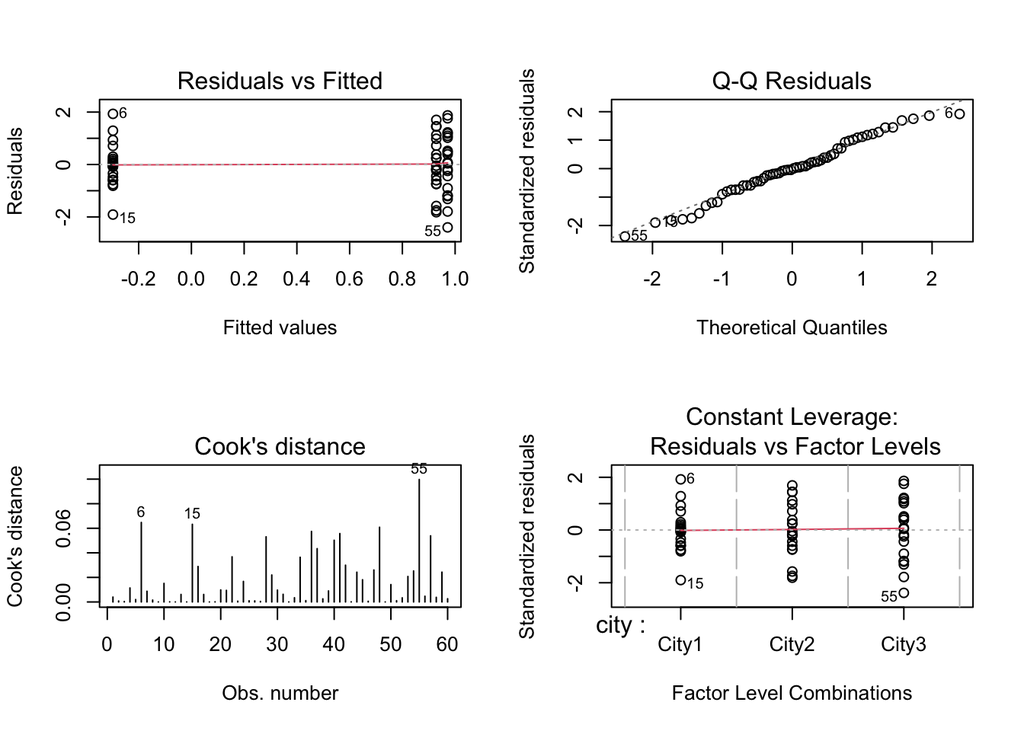

Both problems from the previous model appear to be corrected. The $R^2$ has also improved a bit. We continue with this model.

- Estimate all model parameters from the latter model. Explain what the parameters measure given the paramtrization you have used.

**Solution**

The ANOVA analysis using sum-to-zero parametrization gave the following results.

```r
coefs <- citymod2$coefficients
```

We observe that $R^2 = 0.25$ indicating that there is still a lot of unexplained variability in the response. We get the following estimates for the city means of log(chlorine)-levels using this parametrization. The $\mu$ can be interpreted as a general expected log(chlorine)-level for all three cities, which is estimated to be $\hat{\mu}$=0.53 corresponding to $exp(\hat{\mu})$=1.71 on the original scale of chlorine level. Further, city-specific means are estimated as (on th e log-scale):

$\hat{\mu}_1 = \hat{\mu} + \hat{\alpha}_1 =$ -0.3

$\hat{\mu}_2 = \hat{\mu} + \hat{\alpha}_2 =$ 0.93

$\hat{\mu}_3 = \hat{\mu} + \hat{\alpha}_3 = \hat{\mu} -(\hat{\alpha}_1 + \hat{\alpha}_2)=$ 0.97

The estimate of the error variance is $\hat{\sigma}^2 = MSE= SSE/(n-3) = 60.724/57 = 1.065$.

The $\sigma^2$ is the variance for log-chlorine levels measured in the same city.

- State the hypotheses for testing whether the expected chlorine levels differ between the cities, choose a test level $\alpha$ and perform the test. What is the conclusion?

**Solution**

The hypotheses are:
$$H_0: \mu_1 = \mu_2 =
\mu_3$$
versus
$$H_1:\mu_i
\neq\mu_{i'}$$
for at least two different cities $i$ and $i'$. Note:This is by the chosen parametrization equivalent to testing
$$H_0:
\alpha_1 = \alpha_2 = \alpha_3 = 0$$
versus
$$H_1:\alpha_i\neq0$$
for at least one $i \in \{1,2,3\}$. For test-level $\alpha=0.05$ we reject the null-hypothesis if $F>F_{\alpha, 2, 57}$ or if the p-value is smaller than 0.05. Here we observe a very small p-value and reject the null-hypothesis. We claim that the expected log-chlorine levels differ between at least two of the cities, and from the observed means we know that cities 1 and 3 are significantly different since they have the largest observed difference in means. There may also be a significant difference between cities 1 and 2, and 2 and 3, but this should be checked by a pair-wise contrast.

- Test the pairwise differences between the cities using the Tukey test. Which cities are significantly different from each other?

**Solution**

```r
print(simple.glht(citymod2,'city', level=0.95))
```

```
##
##   Simultaneous Confidence Intervals and Tests for General Linear Hypotheses
##
## Multiple Comparisons of Means: Tukey Contrasts
##
##
## Fit: lm(formula = logy ~ city, data = citydata)
##
## Quantile = 2.4064
## Minimum significant difference = 0.7854
## 95% confidence level
##
## Linear Hypotheses:
##                Lower   Center    Upper  Std.Err t value    P(>t)
## City1-City2 -2.01155 -1.22611 -0.44067  0.32639  -3.757 0.001168 **
## City1-City3 -2.05446 -1.26902 -0.48358  0.32639  -3.888 0.000768 ***
## City2-City3 -0.82835 -0.04291  0.74253  0.32639  -0.131 0.990518
## ---
## Signif. codes:  0 '***' 0.001 '**' 0.01 '*' 0.05 '.' 0.1 ' ' 1
## (Adjusted p values reported -- single-step method)
```

```r
cld(simple.glht(citymod2,'city', level=0.95))
```

```
## Tukey's HSD
## Alpha: 0.05
##
##             Mean G1 G2
## City3  0.9715557  A
## City2  0.9286447  A
## City1 -0.2974608     B
```

From the Tukey-corrected p-values (Last column of the Linear hypotheses table) we observe that City 1 and 2 are sognificantly different (at 5% test level). The same goes for City 1 and 3. City 2 and 3 are not significantly different. This can also quickly be seen from the compact letter display at the bottom. From the mean values we see that City 1 has a significantly lower chlorine level than the two other cities.

# 2 Ex-2: Data from the NSR education test

The Norwegian Centre for Science Recruitment (NSR) has an online “education test” where youths may answer a questionnaire to check their so-called cognitive types, their science interest, their preferred learning methods and their interest to various science subjects. The test suggests different areas within the STEM (Science, Technology, Engineering and Mathematics) within which the youth may find suitable work.

We have an excerpt of these data which can be downloaded from Fronter as the NSR.Rdata file. The data.frame `NSRdata` contains two variables, Science and Age (first 5 observations):

```
##     Science Age
## 101     4.2  16
## 102     4.2  16
## 103     4.2  16
## 104     3.0  19
## 105     2.8  16
```

“Science” is an average liking score (scale 1-6) to various STEM-subjects, and “Age” is a factor indicating different age-groups:

- 1: 1-12 yrs
- 13: 13-15 yrs
- 16: 16-19 yrs
- 19: 19-29 yrs
- 30: 30 + yrs
- Perform an analysis of the NSR data to check whether Age influences the liking to STEM subjects. State the model, fit the model, check model assumptions, test hypotheses, and give model critique. Write a short summary of the results.

**Solution**

```r
NSRmod <- lm(Science ~ Age, data = NSRdata)
anova(NSRmod)
```

```
## Analysis of Variance Table
##
## Response: Science
##             Df  Sum Sq Mean Sq F value    Pr(>F)
## Age          4   224.8  56.205  54.698 < 2.2e-16 ***
## Residuals 9995 10270.5   1.028
## ---
## Signif. codes:  0 '***' 0.001 '**' 0.01 '*' 0.05 '.' 0.1 ' ' 1
```

```r
pt <- simple.glht(NSRmod, "Age", corr = c("Tukey"),level = 0.95)
print(pt)
```

```
##
##   Simultaneous Confidence Intervals and Tests for General Linear Hypotheses
##
## Multiple Comparisons of Means: Tukey Contrasts
##
##
## Fit: lm(formula = Science ~ Age, data = NSRdata)
##
## Quantile = 2.7283
## Minimum significant difference = 0.1567
## 95% confidence level
##
## Linear Hypotheses:
##          Lower   Center    Upper  Std.Err t value    P(>t)
## 1-13   0.04545  0.20212  0.35879  0.05742   3.520  0.00397 **
## 1-16  -0.01827  0.13839  0.29506  0.05742   2.410  0.11263
## 1-19   0.10789  0.26456  0.42123  0.05742   4.607 4.06e-05 ***
## 1-30  -0.34661 -0.18994 -0.03327  0.05742  -3.308  0.00838 **
## 13-16 -0.22040 -0.06373  0.09294  0.05742  -1.110  0.80148
## 13-19 -0.09423  0.06244  0.21911  0.05742   1.087  0.81318
## 13-30 -0.54873 -0.39206 -0.23540  0.05742  -6.828  < 2e-16 ***
## 16-19 -0.03050  0.12617  0.28284  0.05742   2.197  0.18077
## 16-30 -0.48500 -0.32834 -0.17167  0.05742  -5.718 1.11e-07 ***
## 19-30 -0.61117 -0.45450 -0.29783  0.05742  -7.915  < 2e-16 ***
## ---
## Signif. codes:  0 '***' 0.001 '**' 0.01 '*' 0.05 '.' 0.1 ' ' 1
## (Adjusted p values reported -- single-step method)
##
##
## WARNING: Unbalanced data may lead to poor estimates
```

The anova table indicates a clear significance of Age-group with regard to the interest level to Science subjects. Hence, at least two age-groups are have significantly different expected means. We can use the Tukey test to identify pairwise differences.

The Tukey output provides differences in mean (column “center”) between all pairs of groups, and at the top of output the minimum difference yielding a significant difference in means is given to be 0.1567. That is, all age-groups with a difference in averages of more than 0.1567 are significantly different, according to Tukey. From the p-values we observe that 6 out of 10 pairs are significantly different, and the largest difference is found between age groups 30+ and 19-29.

```r
cld(pt)
```

```
## Tukey's HSD
## Alpha: 0.05
##
##        Mean G1 G2 G3
## 30 3.333151  A
## 1  3.143210        C
## 16 3.004815     B  C
## 13 2.941086     B
## 19 2.878647     B
```

The compact letter display gives a grouping of the similar levels, and there are three groups of levels that are internaly non-significantly different. 30+ is different from all other levels, whereas 1-12 and 16-19 are similar and 16-19, 13-15 and 19-29 are also similar.